# Time Series Homework: Chapter 3 Lesson 1

Tristan Farrow

## Data

```r
manu <- rio::import("https://byuistats.github.io/timeseries/data/constructionequip_manu_orders_shipments.csv")
```

## Questions

### Question 1 - Context and Measurement (10 points)

The first part of any time series analysis is context. You cannot properly analyze data without knowing what the data is measuring. Without context, the most simple features of data can be obscure and inscrutable. This homework assignment will center around the series below.

Please research the time series. In the spaces below, give the data collection process, unit of analysis, and meaning of each observation for the series.

##### a) **Construction Equipment Manufacturing Orders and Shipments**

https://fred.stlouisfed.org/graph/?g=1f4dN

**Answer**

This time series includes Manufacturers’ New Orders: Construction Machinery (A33CNO) and Manufacturers’ Value of Shipments: Construction Machinery (A33CVS)

Data Collection:

Both of these data sets are collected by the Census Bureau through their M3 survey. The M3 has between 5,000-6,000 manufacturing establishments around the U.S. that participate monthly through mail, phone, and electronic reporting.

Unit of Analysis:

A33CNO - The value in millions of USD of new purchase orders received during the month by construction machinery manufacturers.

A33CVS - The value is millions of USD of construction machinery actually shipped during the month.

Meaning of Observations:

A33CNO represents a demand for the future production of construction machinery and is a leading indicator for manufacturing activity in the sector.

A33CVS measures the realized production wihtin that month and reflects how much of the new order backlog was converted into output.

### Question 2 - Construction Equipment Manufacturing: Graphical Analysis (15 points)

##### a) Please plot a correlogram of the random components of the New Orders and Value of Shipments for the Construction Equipment Manufacturing data. Include both plots in the same illustration as exemplified in the Figure 5 of Chapter 3 Lesson 1.

**Answer**

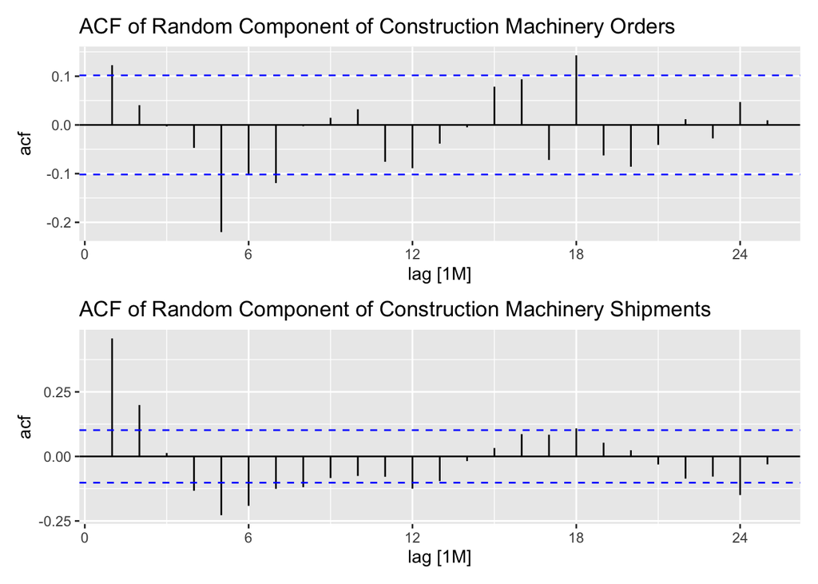

```r
# Create a time series of the data
manu_ts <- manu %>%
  mutate(
    date2 = mdy(date),
    year_mon = yearmonth(date2)
  ) %>%
  select(year_mon, constructionequip_ord, constructionequip_ship) %>%
  tsibble(index = year_mon)

# Create the first decomp model
order_decomp <- manu_ts %>%
  model(feasts::classical_decomposition(constructionequip_ord, type = "mult")) %>%
  components() %>%
  select(year_mon, random) %>%
  rename(random_order = random)

# Create the second decomp model
ship_decomp <- manu_ts %>%
  model(feasts::classical_decomposition(constructionequip_ship, type = "mult")) %>%
  components() %>%
  select(year_mon, random) %>%
  rename(random_ship = random)

acf_order <- ACF(order_decomp, y = random_order) %>%
  autoplot() +
  labs(title = "ACF of Random Component of Construction Machinery Orders")

acf_ship <- ACF(ship_decomp, y = random_ship) %>%
  autoplot() +
  labs(title = "ACF of Random Component of Construction Machinery Shipments")

acf_order / acf_ship
```

2. Interpret and analyze the correlogram of the New Orders and Value of Shipments series.

**Answer**

### Question 3 - Construction Equipment Manufacturing: Cross-correlation (30 points)

##### a) Please plot a cross-correlogram of the New Orders and Value of Shipments series.

**Answer**

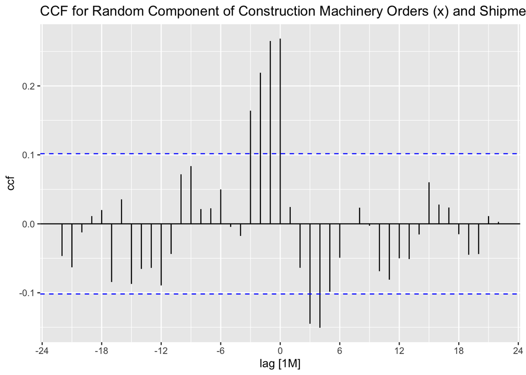

```r
random_join <- order_decomp %>%
  right_join(ship_decomp, by = join_by(year_mon))

random_join %>%
  CCF(y = random_ship, x = random_order) %>%
  autoplot() +
  labs(title = "CCF for Random Component of Construction Machinery Orders (x) and Shipments (y)")
```

##### b) Please interpret the cross-correlogram of the New Orders and Value of Shipments series. Include descriptions of the statistical and practical significance of the results.

**Answer**

The lags closed to zero appear to be practically significant and indicate that the level of orders is a leading a indicator shipments like would be expected.

### Rubric

[output not shown]